# ECo 602 - Analysis of Environmental Data

Final Project Template: Data Analysis

Heather Parry

Fall 2020

# Introduction

This is the final project for the ECO 602 :Analysis of Environmental Data class. The first part of this document consists of examples of commonly used R code to accomplish data analysis for this class.

Part 2 of this project is a data analysis of a data set of Delomys species looking at species and sex effects on body mass of the animals.

# Functions 1: Data Structure Functions

## `c()`

The function `c()` *combines* or *concatenates* its arguments into a vector (a 1-dimensional data structure consisting of 1 or more elements).

- All of the elements must be of the same *type*.
  - I can’t combine character and numeric types in the same call to `c()`

Here’s two examples using numeric and character data types:

```r
# Create a vector of numbers:
num_vec  = c(1, 4, 8, 9, 13)

# Create a vector of characters:
char_vec = c("a", "fish", "data is cool")
```

I can show the contents of a vector by typing the name of the vector, or using the `print()` function.

```r
# Typing the name of the vector into the console prints the contents
num_vec
```

```
## [1]  1  4  8  9 13
```

```r
# The print() function accomplishes the same task:
print(char_vec)
```

```
## [1] "a"            "fish"         "data is cool"
```

## `data.frame()`

A data frame can hold numeric, character or logical data types. Within a column all elements have the same data type, but different columns can be of different data type.

```r
data.frame(letters = c("b", "w", "B"),
           numbers_1 = c(34, 6, 123454))
```

```
##   letters numbers_1
## 1       b        34
## 2       w         6
## 3       B    123454
```

## `matrix()`

A matrix is an array that can hold numeric, character or logical data types but it can only hold one data type at a time.

The first argument (1:12) is the collection of elements that R will arrange into the rows and columns of the matrix.

The second argument `byrow` tells R that the matrix is filled by the rows. If you want the matrix to be filled by the columns, we just place byrow = FALSE.

The third argument `nrow` tells R how many rows there should be in the matrix.

```r
matrix(1:12, byrow = TRUE, nrow = 3)
```

```
##      [,1] [,2] [,3] [,4]
## [1,]    1    2    3    4
## [2,]    5    6    7    8
## [3,]    9   10   11   12
```

## `length()`

The `length()` function gives you the number of elements in a vector or list. In the vector example above we made a vector with 5 elements called `num_vec`. We can find the number of elements in `num_vec` by using `length()`.

```r
# num_vec is a vector we created in the vector example
num_vec  = c(1, 4, 8, 9, 13)

length(num_vec)
```

```
## [1] 5
```

## `nrow()`

The function `nrow()` will tell you how many rows are in your data set. This can be very useful if you are trying to find out how many observations are in your dataset, if each row is one observation.

```r
# I created an example data frame called example_dat
example_dat =data.frame(letters = c("b", "w", "B"),
           numbers_1 = c(34, 6, 123454))

# I printed the data frame to look at the constructed data frame
print(example_dat)
```

```
##   letters numbers_1
## 1       b        34
## 2       w         6
## 3       B    123454
```

```r
# to find the number of rows in example_dat, I used the nrow() function
nrow(example_dat)
```

```
## [1] 3
```

## `ncol()`

The `ncol()` function will tell you the number of columns in your data frame. I will use the data frame from `nrow()` called example_dat to illustrate how to use `ncol()`

```r
# I printed the example_dat data frame to compare the data frame to the results from ncol(example_dat
print(example_dat)
```

```
##   letters numbers_1
## 1       b        34
## 2       w         6
## 3       B    123454
```

```r
ncol(example_dat)
```

```
## [1] 2
```

There are two columns in the data frame, “letters” and “numbers_1” and the ncol() function also told us that there are 2 columns in the data frame.

## `dim()`

The `dim()` function tells you the dimensions of the data frame, or matrix. Again I used the data frame from the previous examples called “example_dat”

```r
dim(example_dat)
```

```
## [1] 3 2
```

The results from dim(example_dat) tells us that that data frame consists of 3 rows and 2 columns.

# Functions 2: Numerical Data Exploration

## `summary()`

The `summary()` function allows you to view all of the numerical summaries of the statistics for the data frame that you are interested in examining.

```r
library(here)
#I downloaded the catrate data into R and convert it to a data frame with the read.csv(here(...)) function
catrate = read.csv(here("data", "catrate.csv"))

# to get the summary of the catrate data I used the summary() function
summary(catrate)
```

```
##       pond       success          years          cat.rate
##  Min.   : 2   Min.   :0.000   Min.   :1.000   Min.   :0.1429
##  1st Qu.: 5   1st Qu.:1.000   1st Qu.:3.000   1st Qu.:0.2857
##  Median : 8   Median :2.000   Median :4.000   Median :0.4286
##  Mean   : 8   Mean   :2.538   Mean   :4.692   Mean   :0.5394
##  3rd Qu.:11   3rd Qu.:5.000   3rd Qu.:7.000   3rd Qu.:0.7500
##  Max.   :14   Max.   :6.000   Max.   :7.000   Max.   :1.0000
```

## `mean()`

To find the mean value of a category or column in your data frame you can use the `mean()` function.

```r
# I want to find the mean value of the catastrophic rate in my data frame catrate.
mean(catrate$cat.rate) # $ allow you to pull out the column in the data that you are interested in.
```

```
## [1] 0.5393773
```

## `sd()`

To find the standard deviation value of a category or column in your data frame you can use the `sd()` function.

```r
# I want to find the standard deviation value of the catastrophic rate in my data frame named catrate.
sd(catrate$cat.rate)
```

```
## [1] 0.3090421
```

# Functions 3: Graphical Data Exploration

## `plot()`

I can use a `plot()` to create a scatterplot

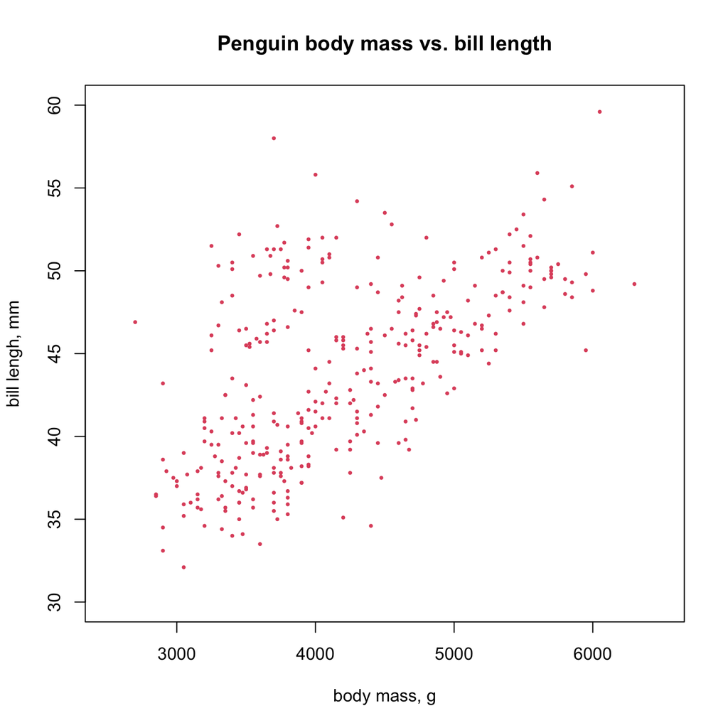

```r
#load the penguin package
require(palmerpenguins)


plot(bill_length_mm~ body_mass_g,
     data= penguins,
     col = 2, # col is the color of the points
     pch = 16, # pch is the symbols used in the scatterplot
     cex = .5, # cex is the size of the points
     main= "Penguin body mass vs. bill length",
     xlab = "body mass, g",
     ylab = "bill lengh, mm",
     xlim = c(2500, 6500),
     ylim = c(30, 60)) # xlim and ylim are the limits of the x and y axis and are in a vector form
```

## `boxplot()`

I can use `boxplot()` to make a simple or conditional boxplot.

Below is a simple boxplot looking at the body mass of all of the penguins in the Palmer Penguins dataset.

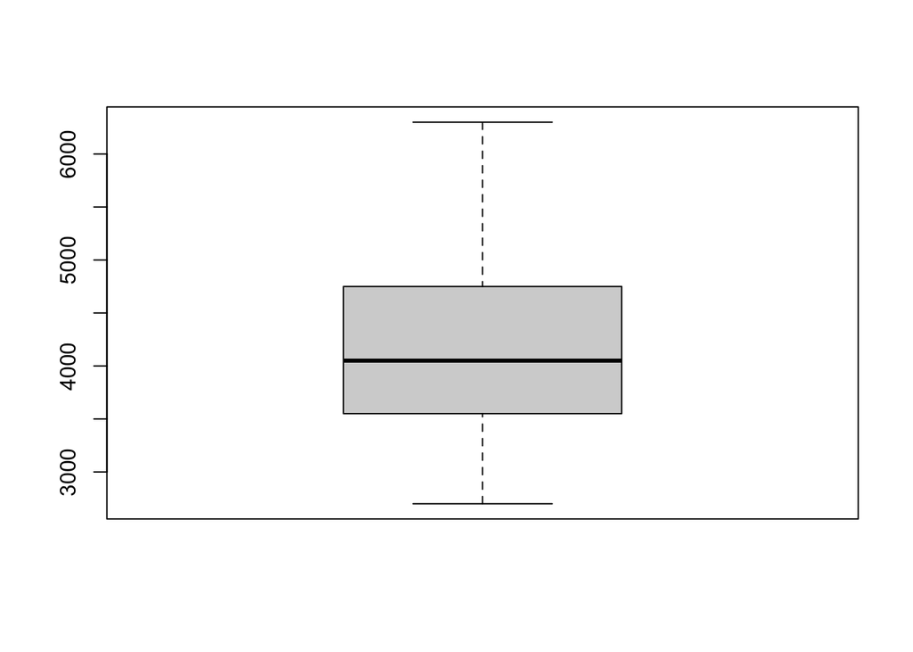

```r
require(palmerpenguins)
penguins<- penguins

boxplot(penguins$body_mass_g)
```

The conditional boxplot below looks at the body mass of the penguins in the Palmer Penguin dataset by their species.You can also add titles and axis labels to boxplots, this is accomplished in the same format as in the scatterplots.

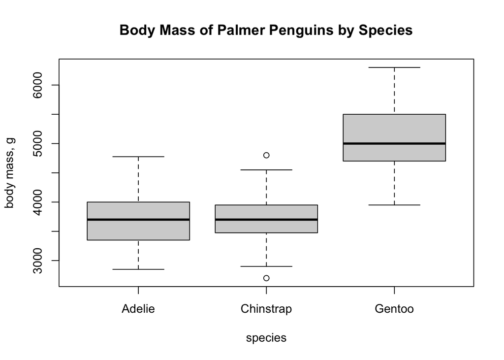

```r
boxplot(body_mass_g ~ species, data = penguins,
        main = "Body Mass of Palmer Penguins by Species",
        ylab = "body mass, g")
```

## `hist()`

Below is a histogram of the body mass of all of the penguins in the Palmer Penguins dataset using `hist()`

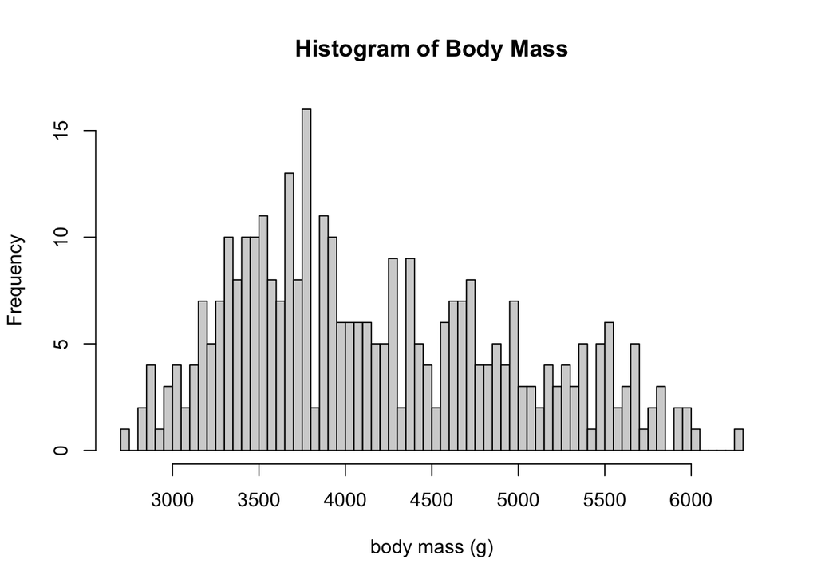

```r
hist(penguins$body_mass_g,
     breaks = 80, #breaks = is the number of columns that the histogram is broken up into.
     main = "Histogram of Body Mass",#main = is the title of the histogram
     xlab = "body mass (g)")#xlab = is the label of the x axis
```

## `par ()`

The `par()` function allows you to arrange multiple plots in one window.

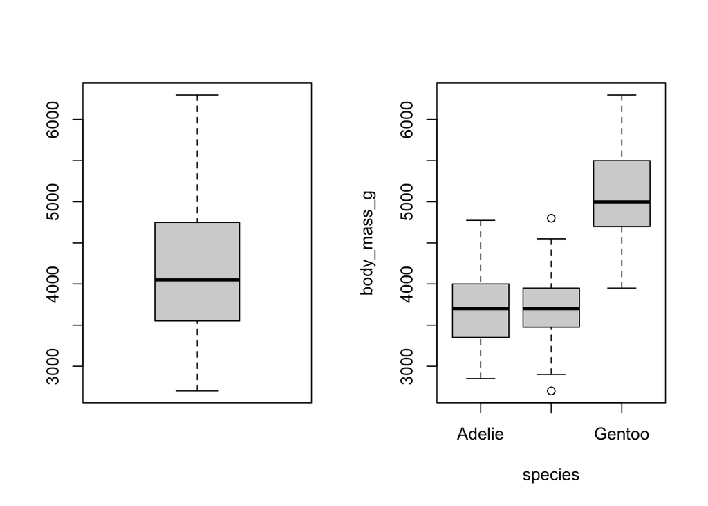

```r
par(mfrow = c(1,2))#mfrow() tells R how to arrange the boxplots. c(1,2) tells R to arrange them with 1 row and 2 columns
boxplot(penguins$body_mass_g)
boxplot(body_mass_g ~ species, data = penguins)
```

```r
dev.off()#dev.off() clears the plot window
```

# Functions 4: Distribution Functions

The dnorm(), pnorm() and qnorm() functions are used for continuous normal distributions. dbinom(), pbinom() and qbinom() are binomial functions used for discrete distributions.

## `dnorm()`

dnorm is the normal probability density function. You can us it to answer questions such as: is the value of 1.2 or 2.4 more likely?

```r
# the parameters required for dnorm() are x, mean and sd. The default setting are as follows dnorm(x, mean = 0, sd = 1, log = FALSE)
dnorm(1.2)
```

```
## [1] 0.1941861
```

```r
dnorm(2.4)
```

```
## [1] 0.02239453
```

## `pnorm()`

pnorm is the normal cumulative density function. You can use this function to answer questions such as: what is the probability of observing a value of less than 1.2 from a normally-distributed population with mean = 2 and standard deviation = 3?

```r
# This gives you the values under the curve to the left (less than) the given value.
pnorm(1.2, mean = 2, sd = 3)
```

```
## [1] 0.3948629
```

```r
# To find the values under the curve to the right of the given value (greater than) you need to use the law of probabilty like in the example below

1- pnorm(1.2, mean = 2, sd = 3)
```

```
## [1] 0.6051371
```

## `qnorm()`

qnorm is the normal quantile function. You can answer questions such as: what is the 20th percentile of your data which has a mean of 5 and a standard deviation of 1?

```r
qnorm(.2, mean = 5, sd = 1)
```

```
## [1] 4.158379
```

## `dbinom()`

dbinom is the binomial probability mass function. You can use these function to answer questions such as: what is the probability of observing exactly x = 3 with a sample size of 4 and a probability of .75?

```r
dbinom(3, size = 4, prob = 0.75)
```

```
## [1] 0.421875
```

## `pbinom()`

pbinom is the binomial cumulative mass function. This function lets you answer questions such as: what is the probability of observing a count of x = 3 successes or fewer in a binomial distribution with a sample size of n = 4 and probability of p = 0.75?

```r
pbinom(3, size = 4, prob = 0.75)
```

```
## [1] 0.6835937
```

You can use the law of probability to figure out the reciprocal value. What is the probability of observing a count of greater than 3 successes in a binomial distribution with a sample size of n = 4 and probability of p = 0.75?

```r
1- pbinom(3, size = 4, prob = 0.75)
```

```
## [1] 0.3164063
```

## `qbinom()`

qbinom is the binomial quantile function. You can use this function to answer questions such as: what is the 10th quantile of a binomial distribution with a sample size of 10 and a probability of success for each trial of .4?

```r
qbinom(.10, size = 10, prob = .4)
```

```
## [1] 2
```

# Functions 5: Other Functions

## `subset()`

The `subset()` function allows you to subset a dataset. In the example below I was able to separate the Gentoo penguins’ data from the rest of the data frame. I reassigned the subset to gentoo_penguins.

```r
require(palmerpenguins)# import palmer penguin data in to R
penguins<- penguins #assign data the name penguins
gentoo_penguins= subset(penguins,species == "Gentoo") #penguins is the dataframe, species =="Gentoo" allows us to select only the data for the species Gentoo.
```

## `$`

The `$` allows you to pull out a column of data by name from you data set. In the example below I pulled the body mass data out of the gentoo_penquins dataframe.

```r
gentoo_penguins$body_mass_g # gentoo_penguins is a dataframe that I created in the subset example above.
```

```
##   [1] 4500 5700 4450 5700 5400 4550 4800 5200 4400 5150 4650 5550 4650 5850 4200
##  [16] 5850 4150 6300 4800 5350 5700 5000 4400 5050 5000 5100 4100 5650 4600 5550
##  [31] 5250 4700 5050 6050 5150 5400 4950 5250 4350 5350 3950 5700 4300 4750 5550
##  [46] 4900 4200 5400 5100 5300 4850 5300 4400 5000 4900 5050 4300 5000 4450 5550
##  [61] 4200 5300 4400 5650 4700 5700 4650 5800 4700 5550 4750 5000 5100 5200 4700
##  [76] 5800 4600 6000 4750 5950 4625 5450 4725 5350 4750 5600 4600 5300 4875 5550
##  [91] 4950 5400 4750 5650 4850 5200 4925 4875 4625 5250 4850 5600 4975 5500 4725
## [106] 5500 4700 5500 4575 5500 5000 5950 4650 5500 4375 5850 4875 6000 4925   NA
## [121] 4850 5750 5200 5400
```

## `[]`

The `[]` also allows you to select a column in your data frame but you need to know what number column you are looking for. In this example I knew that body mass was the 6th column in the data frame

```r
gentoo_penguins[6]# the 6 column is the body mass column
```

```
##     body_mass_g
## 153        4500
## 154        5700
## 155        4450
## 156        5700
## 157        5400
## 158        4550
## 159        4800
## 160        5200
## 161        4400
## 162        5150
## 163        4650
## 164        5550
## 165        4650
## 166        5850
```

[output cut: 110 more lines]

## `libary()` and `require()`

Both library() and require() access the library where packages in R are stored. Packages in R contain functions that you may want to access. Palmer Penguins is a package in R so using libary() or require() will allow you to access that data.

```r
require(palmerpenguins)
penguins<- penguins #I assigned the Palmer Penguins dataset the name penguins
```

## `read.csv()`

The read.csv() function allows you to import a csv file into R. In this example, I downloaded the catrate data into R and convert it to a dataframe with the read.csv(here(…)) function.

```r
catrate = read.csv(here("data", "catrate.csv"))# "here" allows you to find the data that is stored on your computer. "data" is the folder that the the catrate.csv file is saved.
```

# Part 2: Data Anaylsis

This is an analysis of data collected on two species of mammals (Delmoys dorsalis and Delmoys sublineatus) which live in the Atlantic Forests of Brazil.

## Data Exploration

### Numerical Exploration

**Summary**

```r
library(here)
delomys_dat = read.csv(here("data", "delomys.csv"))
summary(delomys_dat$body_mass)
```

```
##    Min. 1st Qu.  Median    Mean 3rd Qu.    Max.
##    5.00   35.00   43.00   44.06   54.00  105.00
```

```r
summary(delomys_dat$body_length)
```

```
##    Min. 1st Qu.  Median    Mean 3rd Qu.    Max.
##    49.0   106.0   116.0   114.7   124.0   265.0
```

**Shapiro- Wilk Normality test**

```r
shapiro.test(delomys_dat$body_mass)
```

```
##
##  Shapiro-Wilk normality test
##
## data:  delomys_dat$body_mass
## W = 0.99506, p-value = 4.33e-05
```

```r
shapiro.test(delomys_dat$body_length)
```

```
##
##  Shapiro-Wilk normality test
##
## data:  delomys_dat$body_length
## W = 0.87609, p-value < 2.2e-16
```

### Graphical Exploration

**Scatterplot of body length and body mass**

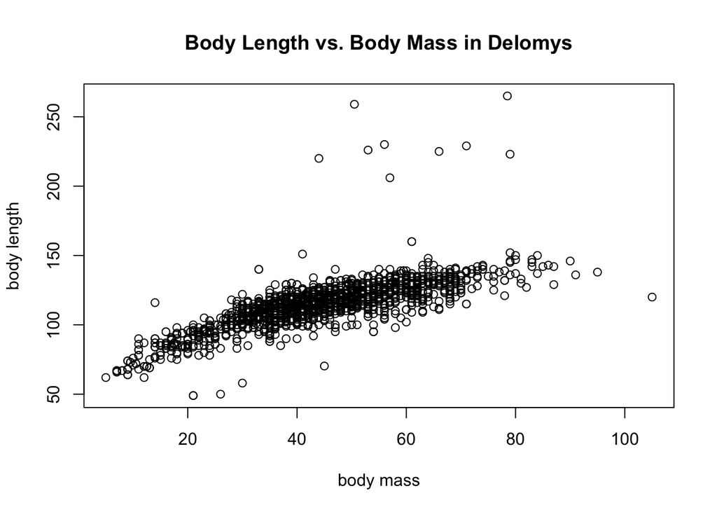

```r
plot(body_length ~ body_mass,
     data= delomys_dat,
     main = "Body Length vs. Body Mass in Delomys",
     xlab = "body mass",
     ylab = "body length")
```

**Histograms**

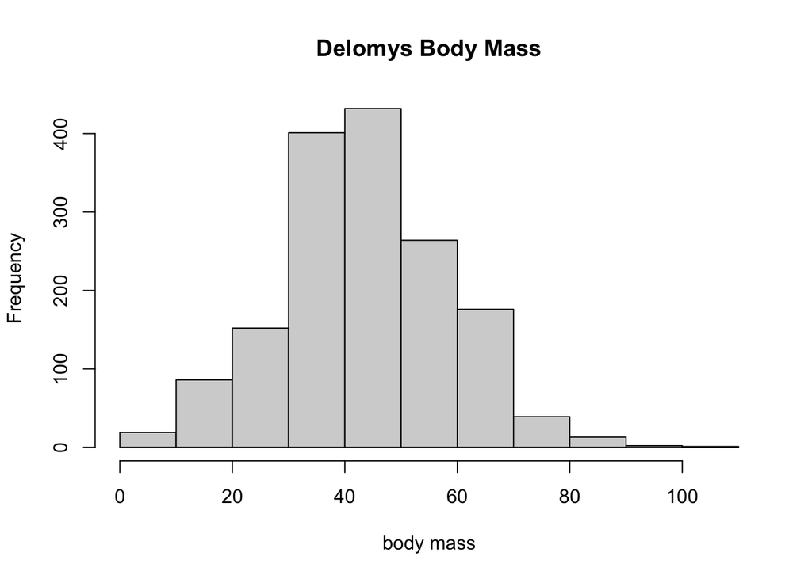

```r
hist(delomys_dat$body_mass,
     main = "Delomys Body Mass",
     xlab = "body mass")
```

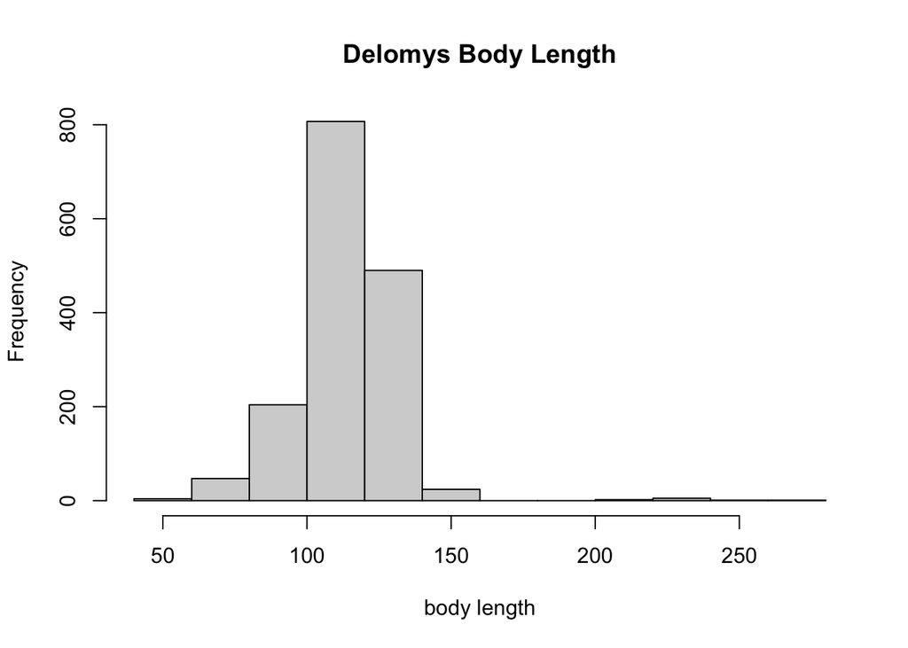

```r
hist(delomys_dat$body_length,
     main = "Delomys Body Length",
     xlab = "body length")
```

**Boxplots**

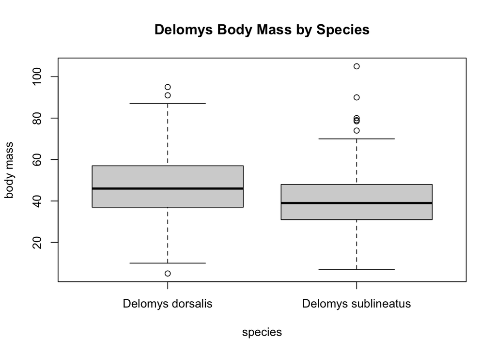

```r
boxplot(body_mass ~ binomial, data = delomys_dat,
        main = "Delomys Body Mass by Species",
        xlab = "species",
        ylab = "body mass")
```

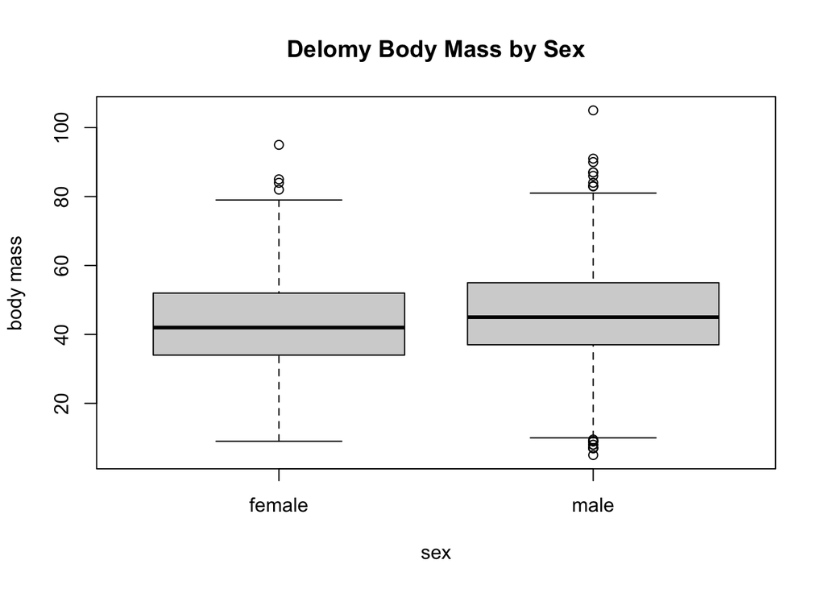

```r
boxplot(body_mass ~ sex, data = delomys_dat,
        main = "Delomy Body Mass by Sex",
        xlab = "sex",
        ylab = "body mass")
```

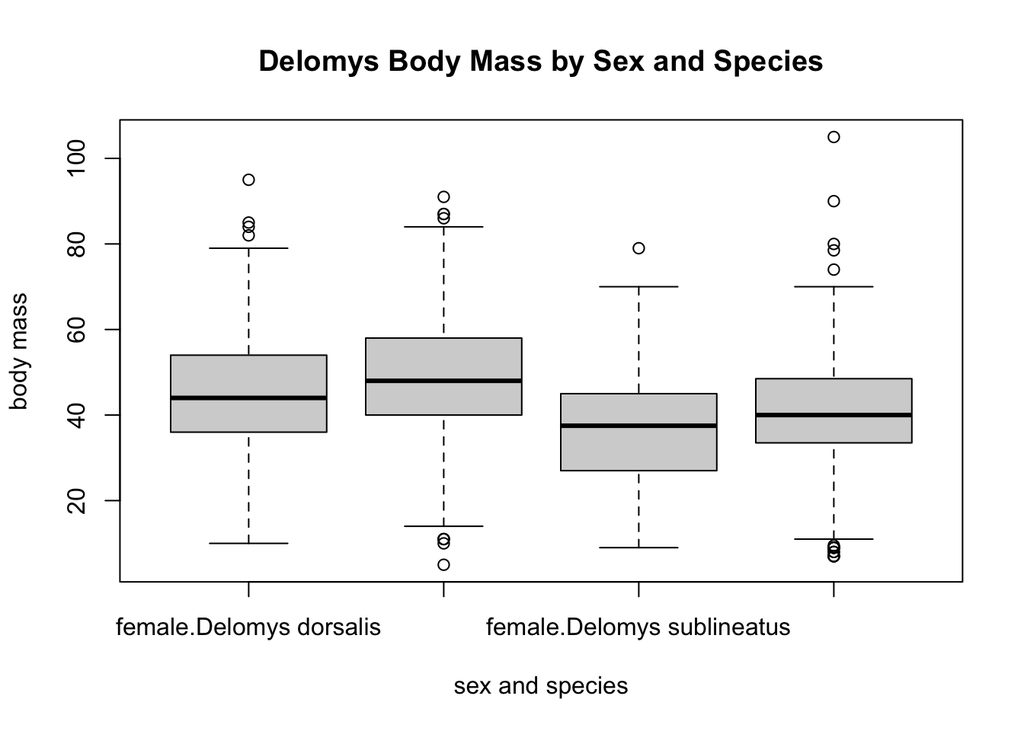

```r
boxplot(body_mass ~ sex * binomial, data = delomys_dat,
        main = "Delomys Body Mass by Sex and Species",
        xlab = "sex and species",
        ylab = "body mass")
```

**Questions**

1. The scatterplot of body length vs. body mass indicates that as the body length increases so does the body mass of the animals. The relationship between body length and body mass seems linear or slightly curved.
2. The body mass histogram seems to have a normal distribution except that there are large values on the right side of the histogram. It makes it look like there is a tail coming off the right side of the graph. The body length histogram also looks normally distributed except for a long tail off to the right side of the graph. This histogram doesn’t look as much like a normal distribution as the body mass histogram
3. The histograms seem to indicate that the data might not be normally distributed because of the long tails on the right side of the graphs, but it didn’t clearly indicate that it was non-normal. The Shapiro tests confirm that the distribution was not normal. The p-values for for the body mass and the body length of very small indicating that the data is not normally distributed.
4. Looking at the boxplots it appears that species might have an effect on body mass. The mean value of the Delomys sublineatus looks smaller than the Delomys dorsalis. Sex by itself doesn’t seem to effect body mass.

## Model Building

**Model 1: simple linear regression**

```r
fit1 = lm(body_length ~ body_mass, data = delomys_dat)
```

**Model 2: 1-way ANOVA body_mass ~ sex**

```r
fit2 = lm(body_mass ~ sex, data = delomys_dat)
```

**Model 3: 1-way ANOVA body_mass ~ binomial**

```r
fit3 = lm(body_mass ~ binomial, data = delomys_dat)
```

**Model 4: 2 additive ANOVA body_mass ~ sex + binomial**

```r
fit4 = lm(body_mass ~ sex + binomial, data = delomys_dat)
```

**Model 5: 2-way factorial ANOVA**

```r
fit5 = lm(body_mass ~ sex * binomial, data = delomys_dat)
```

## Model Diagnostic

**Residuals fit1**

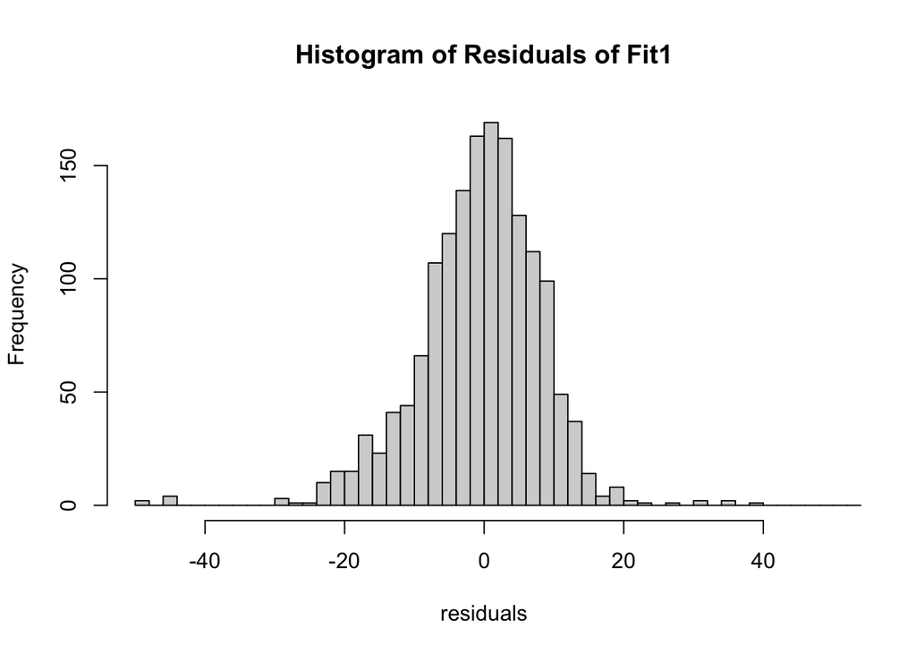

```r
resids_fit1 = residuals(fit1)
hist(resids_fit1,
     main = "Histogram of Residuals of Fit1",
     xlab = "residuals",
     breaks = 80,
     xlim = c(-50, 50))
```

```r
shapiro.test(resids_fit1)
```

```
##
##  Shapiro-Wilk normality test
##
## data:  resids_fit1
## W = 0.73462, p-value < 2.2e-16
```

**Residuals fit2**

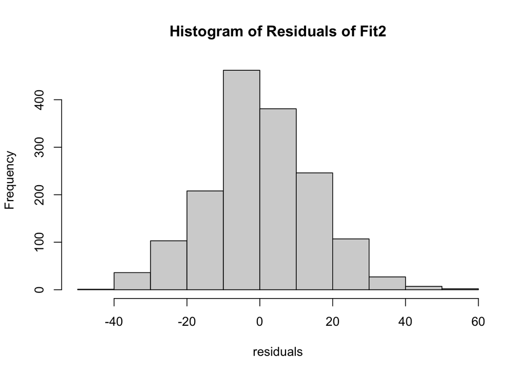

```r
resids_fit2 = residuals(fit2)
hist(resids_fit2,
     main = "Histogram of Residuals of Fit2",
     xlab = "residuals",
     breaks = 10)
```

```r
shapiro.test(resids_fit2)
```

```
##
##  Shapiro-Wilk normality test
##
## data:  resids_fit2
## W = 0.99563, p-value = 0.0001541
```

**Residuals fit3**

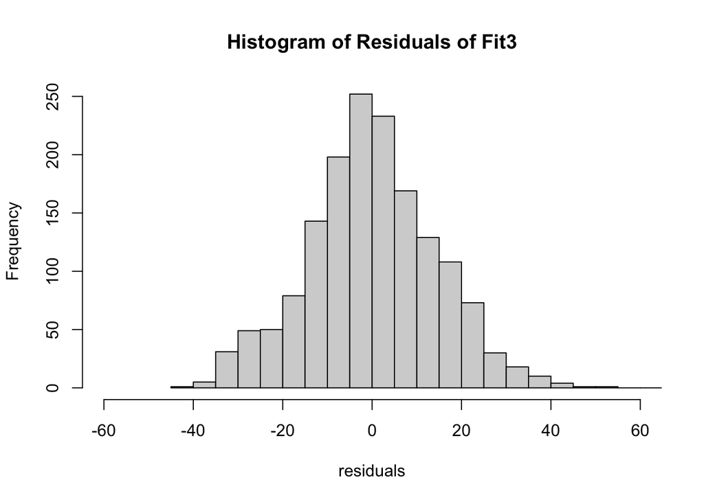

```r
resids_fit3 = residuals(fit3)
hist(resids_fit3,
     main = "Histogram of Residuals of Fit3",
     xlab = "residuals",
     breaks = 20,
     xlim = c(-60, 60))
```

```r
shapiro.test(resids_fit3)
```

```
##
##  Shapiro-Wilk normality test
##
## data:  resids_fit3
## W = 0.99535, p-value = 8.103e-05
```

**Residuals fit4**

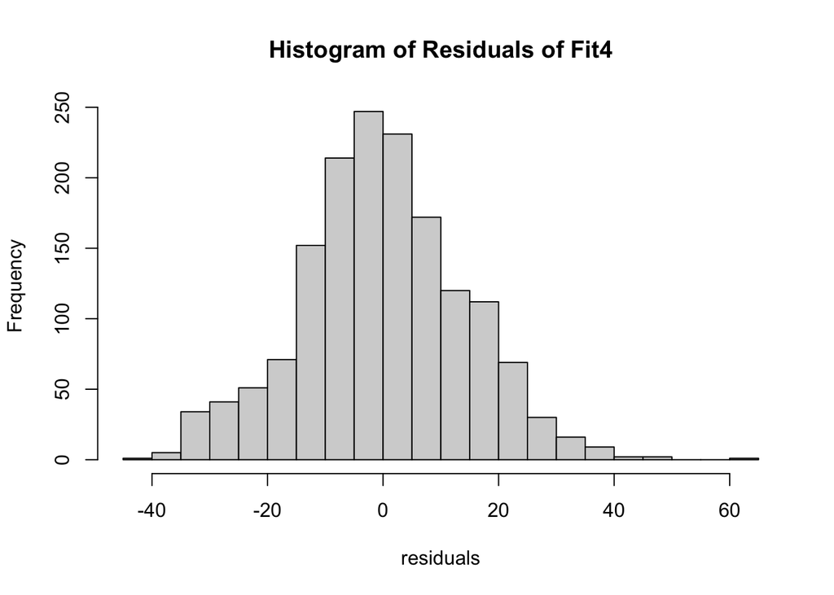

```r
resids_fit4 = residuals(fit4)
hist(resids_fit4,
     main = "Histogram of Residuals of Fit4",
     xlab = "residuals",
     breaks = 20)
```

```r
shapiro.test(resids_fit4)
```

```
##
##  Shapiro-Wilk normality test
##
## data:  resids_fit4
## W = 0.99525, p-value = 6.805e-05
```

**Residuals fit5**

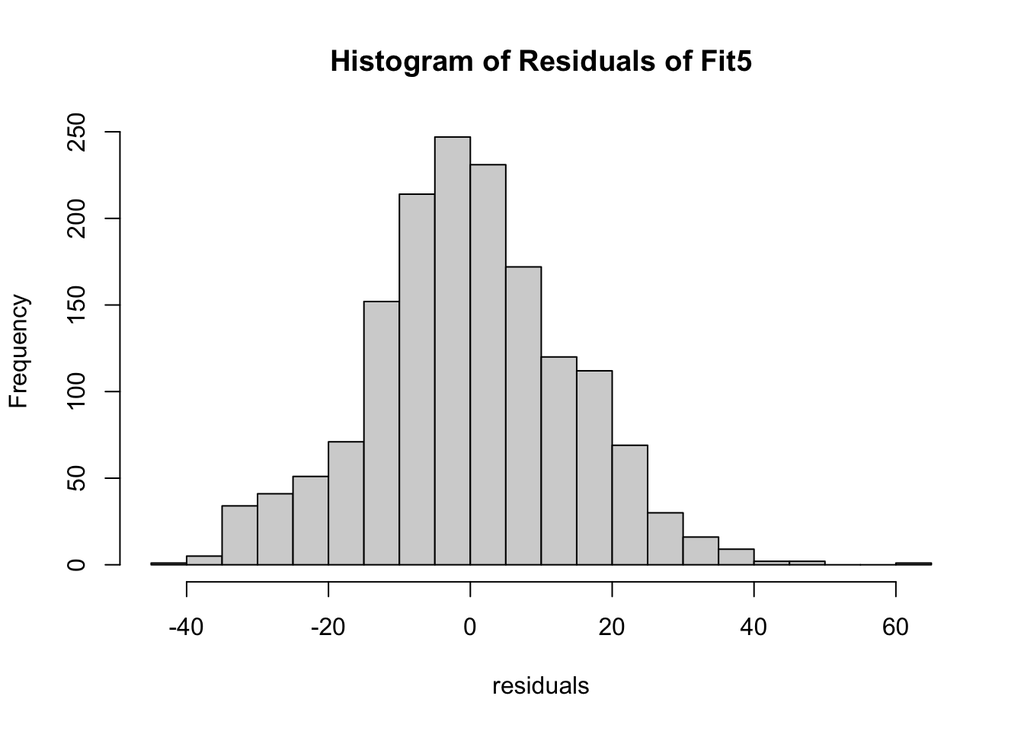

```r
resids_fit5 = residuals(fit5)
hist(resids_fit5,
     main = "Histogram of Residuals of Fit5",
     xlab = "residuals",
     breaks = 20)
```

```r
shapiro_resids_5 = shapiro.test(resids_fit5)
```

**Questions**

## Model Interpretation

### Body Length

**Model fit 1: Simple linear regression**

`body_length ~ body_mass`

```r
knitr::kable(coef(summary(fit1)), digits = 2)
```

|  | Estimate | Std. Error | t value | Pr(>\|t\|) |
| --- | --- | --- | --- | --- |
| (Intercept) | 76.12 | 0.92 | 83.12 | 0 |
| body_mass | 0.88 | 0.02 | 44.46 | 0 |

**Questions**

1. The magnitude of the mass/length relationship is .88.
2. The expected body length of an animal that weights 100g is 164.12.
3. The expected body length of an animal that weighs 0g is 76.12

### Body Mass : Model Coeffiecients

**Coefficient Tables**

**Model fit 1: Simple linear regression**

`body_length ~ body_mass`

```r
knitr::kable(coef(summary(fit1)), digits = 2)
```

|  | Estimate | Std. Error | t value | Pr(>\|t\|) |
| --- | --- | --- | --- | --- |
| (Intercept) | 76.12 | 0.92 | 83.12 | 0 |
| body_mass | 0.88 | 0.02 | 44.46 | 0 |

**Model fit 2** 1-way ANOVA `body_mass ~ sex`**

```r
knitr::kable(coef(summary(fit2)), digits = 2)
```

|  | Estimate | Std. Error | t value | Pr(>\|t\|) |
| --- | --- | --- | --- | --- |
| (Intercept) | 42.71 | 0.53 | 80.76 | 0 |
| sexmale | 2.78 | 0.75 | 3.73 | 0 |

**Model fit 3** 1-way ANOVA `body_mass ~ binomial`

```r
knitr::kable(coef(summary(fit3)), digits = 2)
```

|  | Estimate | Std. Error | t value | Pr(>\|t\|) |
| --- | --- | --- | --- | --- |
| (Intercept) | 46.75 | 0.45 | 103.9 | 0 |
| binomialDelomys sublineatus | -7.68 | 0.76 | -10.1 | 0 |

**Model fit 4** 2-way additive ANOVA `body_mass ~ sex + binomial`

```r
knitr::kable(coef(summary(fit4)), digits = 2)
```

|  | Estimate | Std. Error | t value | Pr(>\|t\|) |
| --- | --- | --- | --- | --- |
| (Intercept) | 45.07 | 0.56 | 81.11 | 0 |
| sexmale | 3.80 | 0.73 | 5.23 | 0 |
| binomialDelomys sublineatus | -8.19 | 0.76 | -10.77 | 0 |

**Model fit 5** 2-way factorial ANOVA `body_mass ~ sex * binomial

```r
knitr::kable(coef(summary(fit5)), digits = 2)
```

|  | Estimate | Std. Error | t value | Pr(>\|t\|) |
| --- | --- | --- | --- | --- |
| (Intercept) | 45.06 | 0.61 | 74.44 | 0.00 |
| sexmale | 3.83 | 0.90 | 4.27 | 0.00 |
| binomialDelomys sublineatus | -8.14 | 1.13 | -7.22 | 0.00 |
| sexmale:binomialDelomys sublineatus | -0.10 | 1.53 | -0.06 | 0.95 |

**Questions**

1. What is the base level for sex? **female**
2. What is the base level for binomial? **Delomys dorsalis**
3. Which sex is heavier? **male**
4. Which species is heavier? **Delmoys dorsalis**

### Body Mass: ANOVA

**ANOVA Tables**

**Model fit 1: Simple linear regression**

`body_length ~ body_mass`

```r
knitr::kable(anova(fit1), digits = 2)
```

|  | Df | Sum Sq | Mean Sq | F value | Pr(>F) |
| --- | --- | --- | --- | --- | --- |
| body_mass | 1 | 269388.9 | 269388.91 | 1976.96 | 0 |
| Residuals | 1583 | 215706.6 | 136.26 | NA | NA |

**Model fit 2** 1-way ANOVA `body_mass ~ sex`

```r
knitr::kable(anova(fit2), digits = 2)
```

|  | Df | Sum Sq | Mean Sq | F value | Pr(>F) |
| --- | --- | --- | --- | --- | --- |
| sex | 1 | 3061.68 | 3061.68 | 13.94 | 0 |
| Residuals | 1578 | 346507.13 | 219.59 | NA | NA |

**Model fit 3** 1-way ANOVA `body_mass ~ binomial`

```r
knitr::kable(anova(fit3), digits = 2)
```

|  | Df | Sum Sq | Mean Sq | F value | Pr(>F) |
| --- | --- | --- | --- | --- | --- |
| binomial | 1 | 21289.68 | 21289.68 | 102.08 | 0 |
| Residuals | 1583 | 330164.45 | 208.57 | NA | NA |

**Model fit 4** 2-way additive ANOVA `body_mass ~ sex + binomial`

```r
knitr::kable(anova(fit4), digits = 2)
```

|  | Df | Sum Sq | Mean Sq | F value | Pr(>F) |
| --- | --- | --- | --- | --- | --- |
| sex | 1 | 3061.68 | 3061.68 | 14.96 | 0 |
| binomial | 1 | 23727.13 | 23727.13 | 115.92 | 0 |
| Residuals | 1577 | 322780.00 | 204.68 | NA | NA |

**Model fit 5** 2-way factorial ANOVA `body_mass ~ sex * binomial

```r
knitr::kable(anova(fit5), digits = 2)
```

|  | Df | Sum Sq | Mean Sq | F value | Pr(>F) |
| --- | --- | --- | --- | --- | --- |
| sex | 1 | 3061.68 | 3061.68 | 14.95 | 0.00 |
| binomial | 1 | 23727.13 | 23727.13 | 115.85 | 0.00 |
| sex:binomial | 1 | 0.79 | 0.79 | 0.00 | 0.95 |
| Residuals | 1576 | 322779.21 | 204.81 | NA | NA |

**Questions**

1. Sex and species are both significant predictors for body mass. The ANOVA tables above all show very small p-values for sex and for species which indicates that both variables are significant predictors of body mass.
2. There is not a significant interaction between species and sex. Fit5 is the model in which there is an interaction between sex and species had a high p-value of .95 for the interaction row of the ANOVA table and an F-value of 0.
3. The p-values for the sex and species do not differ much between the single-predictor and the additive models. They do vary with the interactive model (Fit 5) as seen in the row for the interaction between sex and species which has a large p-value (p-value = .95)

## Model Comparison: Body Mass

**Model fit 2**

```r
AIC(fit2)
```

```
## [1] 13006.8
```

**Model fit 3**

```r
AIC(fit3)
```

```
## [1] 12966.36
```

**Model fit 4**

```r
AIC(fit4)
```

```
## [1] 12896.73
```

**Model fit 5**

```r
AIC(fit5)
```

```
## [1] 12898.72
```

**Questions**

1. Models Fit4 and Fit5 had the lowest AIC. Fit4 is the additive model and Fit5 is the interactive model.
2. I would choose to use model Fit4. It had the lowest AIC score. The additive models are also a less complex model than an interactive model. Also in the ANOVA table of Fit5 the p-value for the interaction between sex and species was very large indicating that there was no significant interaction. So I would select model fit4 because it is the simplest model that explains the species and the sex effect on body mass.